# Encontro 07

Enoch Sousa Filho

01-jul-2020

## Hoje

Ainda sobre visualizações, vimos:

1. FACETAS: diferenças entre `facet_wrap` e `facet_grid`
2. AJUSTES DE POSIÇÃO: position = “dodge”, “stack”, “fill”

Também vimos que para produzir as visualizações/ gráficos, muitas vezes precisamos manipular a base de dados antes plotar os gráficos. Fernanda Caires mostrou a utilização dos 3 tipos de posição utilizados em gráficos com barras, e por fim, apresentou novas versões de gráficos de sua pesquisa.

OBS: Desta vez não utilizei um scrip do R (arquivo.r) mas sim um “R Notebok”. Neste caso o objetivo é que vcs tomem conhecimento da existência de documentos do tipo R markdown.

Para saber mais:

- [Diferença entre R MarkDown e R NoteBook](https://www.it-swarm.dev/pt/r/diferenca-entre-r-markdown-e-r-notebook/832595179/)
- [mais um link](http://sillasgonzaga.com/material/curso_visualizacao/apresentacao-de-dados-com-relatorios.html)
- [outro link](https://bookdown.org/yihui/rmarkdown/)

Abaixo você deve rodar e observar cada chunk. Um chunk começa com “```”. Para roda-los, do lado direito de cada um clique no triângulo verde.

## Carregar os pacotes

```r
# Carregando pacotes:

library(dplyr) # A Grammar of Data Manipulation, CRAN v1.0.0
library(tidyr) # Tidy Messy Data, CRAN v1.1.0
library(ggplot2) # Create Elegant Data Visualisations Using the Grammar of Graphics, CRAN v3.3.2
library(skimr) # Compact and Flexible Summaries of Data, CRAN v2.1.1

# install.packages("fivethirtyeight")
library(fivethirtyeight) # Data and Code Behind the Stories and Interactives at 'FiveThirtyEight', CRAN v0.5.0
```

## Banco de dados de Diamantes

Hoje vamos utilizar o banco de dados de diamantes nessa primeira parte:

```r
data("diamonds")
```

```r
diamonds %>% select(carat, cut, color, price) %>% skim()
```

```
-- Data Summary ------------------------
                           Values
Name                       Piped data
Number of rows             53940
Number of columns          4
_______________________
Column type frequency:
  factor                   2
  numeric                  2
________________________
Group variables            None

-- Variable type: factor ----------------------------------------------
# A tibble: 2 x 6
  skim_variable n_missing complete_rate ordered n_unique
* <chr>             <int>         <dbl> <lgl>      <int>
1 cut                   0             1 TRUE           5
2 color                 0             1 TRUE           7
  top_counts
* <chr>
1 Ide: 21551, Pre: 13791, Ver: 12082, Goo: 4906
2 G: 11292, E: 9797, F: 9542, H: 8304

-- Variable type: numeric ---------------------------------------------
# A tibble: 2 x 11
  skim_variable n_missing complete_rate     mean       sd    p0   p25
* <chr>             <int>         <dbl>    <dbl>    <dbl> <dbl> <dbl>
1 carat                 0             1    0.798    0.474   0.2   0.4
2 price                 0             1 3933.    3989.    326   950
     p50     p75     p100 hist
*  <dbl>   <dbl>    <dbl> <chr>
1    0.7    1.04     5.01 ▇▂▁▁▁
2 2401   5324.   18823    ▇▂▁▁▁
```

## FACETAS

Vamos gerar um gráfico de densidade com todas as observações da variável preço (preço de cada pedra de diamante)

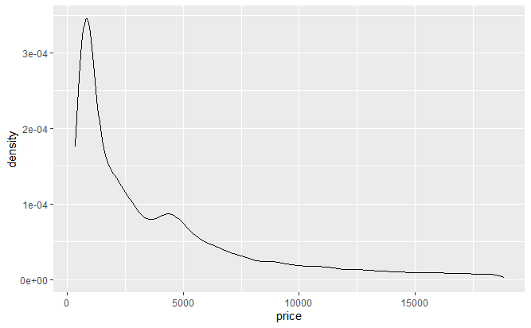

```r
ggplot(diamonds, aes(x = price)) +
  geom_density()
```

### facet_wrap

Então queremos viusualizar o banco de dados desagregando o preço das pedras de acordo com o tipo/ qualidade do corte de cada uma delas (variável `cut`)

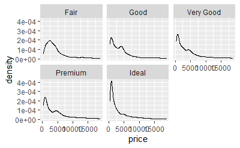

```r
ggplot(diamonds, aes(x = price)) +
  geom_density() +
  facet_wrap(~ cut)
```

Obs: facet_wrap(~ cut) quando usamos o til, isto é uma notação de fórumla. Outra maneira de chamar a faceta seria: facet_wrap(vars(cut)). Também é possível escolher a quantidade de colunas ou linhas em que os gráficos ficarão organizados. Ex: ncol = 2 ou nrow = 2

### facet_grid

Esta faceta é utilizada para desagregar os ainda mais. Desta vez, por duas váriaves.  
Os subgráficos ficam dispostos em formato de matriz.

Aqui, o mesmo gráfico, desta vez abrindo por `cut` (Fair, Good, …) e `color` (D, E,…). Para melhorar a visualização, também estamos mapeando a variável `color` à estética de preenchimento de cor (`fill =`` )

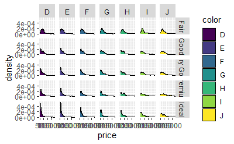

```r
ggplot(diamonds, aes(x = price, fill = color)) +
  geom_density() +
  facet_grid(cut ~ color)
```

```r
# facet_grid(rows = vars(cut), cols = vars(color))
```

A título de visualização, repetiremos o gráfico produzindo histogramas:

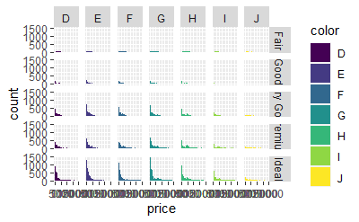

```r
ggplot(diamonds, aes(x = price)) +
  geom_histogram(aes(fill = color)) +
  facet_grid(rows = vars(cut), cols = vars(color))
```

## AJUSTES DE POSIÇÃO

Em seguida, com a colaboração de Fernanda, vimos as possibilidades de ajustes de posicionamento das barras de um gráfico.

Referência: ModernDive, cap 02 e cap 04 seção 4.2

Banco de dados de consumo de bebidas retirado do pacote `fivethirtyeight`

```r
data("drinks")
glimpse(drinks)
```

```
Rows: 193
Columns: 5
$ country                      <chr> "Afghanistan", "Albania", "Algeria", ...
$ beer_servings                <int> 0, 89, 25, 245, 217, 102, 193, 21, 26...
$ spirit_servings              <int> 0, 132, 0, 138, 57, 128, 25, 179, 72,...
$ wine_servings                <int> 0, 54, 14, 312, 45, 45, 221, 11, 212,...
$ total_litres_of_pure_alcohol <dbl> 0.0, 4.9, 0.7, 12.4, 5.9, 4.9, 8.3, 3...
```

Criou-se um novo banco de dados contendo dados selecionados:

```r
drinks_smaller <- drinks %>%
  filter(country %in% c("USA", "China", "Italy", "Saudi Arabia")) %>%
  select(-total_litres_of_pure_alcohol) %>%
  rename(beer = beer_servings,
    spirit = spirit_servings,
    wine = wine_servings
    )
```

Vejamos como ficou:

```r
drinks_smaller
```

| country | beer | spirit | wine |
| --- | --- | --- | --- |
| China | 79 | 192 | 8 |
| Italy | 85 | 42 | 237 |
| Saudi Arabia | 0 | 5 | 0 |
| USA | 249 | 158 | 84 |

Para fazer os gráficos será necessário colocar o banco `drinks_smaller` em formato arrumado (tidy):

```r
drinks_smaller_tidy <- drinks_smaller %>%
  pivot_longer(names_to = "type",
               values_to = "servings",
               cols = -country)
```

Agora sim! Veja:

```r
drinks_smaller_tidy
```

| country | type | servings |
| --- | --- | --- |
| China | beer | 79 |
| China | spirit | 192 |
| China | wine | 8 |
| Italy | beer | 85 |
| Italy | spirit | 42 |
| Italy | wine | 237 |
| Saudi Arabia | beer | 0 |
| Saudi Arabia | spirit | 5 |
| Saudi Arabia | wine | 0 |
| USA | beer | 249 |

[output cut: 2 more lines]

```r
NA
```

Podemos então experimentar as diferentes visualizações:

### Position = “dodge”

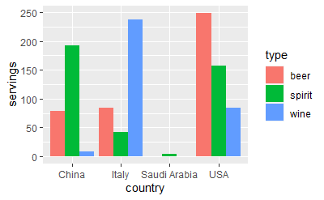

```r
ggplot(drinks_smaller_tidy, aes(x = country, y = servings, fill = type)) +
  geom_col(position = "dodge")
```

### Position = “stack”

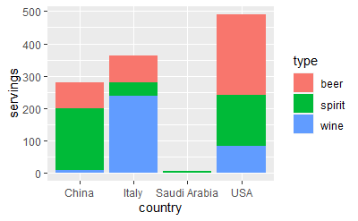

```r
ggplot(drinks_smaller_tidy, aes(x = country, y = servings, fill = type)) +
  geom_col(position = "stack")
```

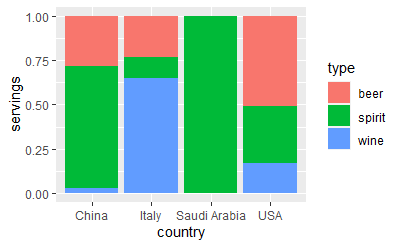

```r
ggplot(drinks_smaller_tidy, aes(x = country, y = servings, fill = type)) +
  geom_col(position = "fill")
```

Gráfico de dispersão

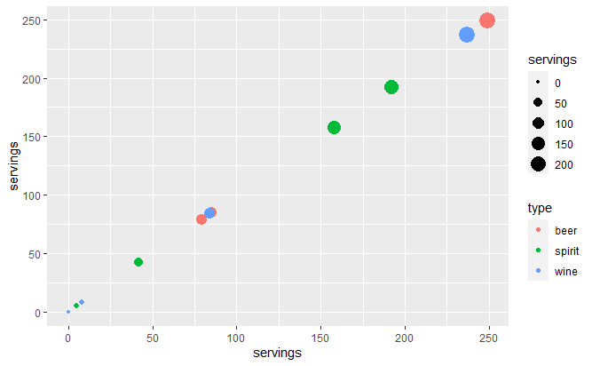

```r
drinks_smaller_tidy %>%
  ggplot( aes(x = servings, y = servings, color = type, size = servings)) +
  geom_point()
```

```r
vendas <- runif(12, 200, 800) %>% round()
```

```r
data.frame(c(
  country = drinks_smaller_tidy$country,
  type = drinks_smaller_tidy$type,
  servings = drinks_smaller_tidy$servings,
  vendas = vendas
  )) %>% head()
```

|  | c.country...drinks_smaller_tidy.country..type...drinks_smaller_tidy.type.. |
| --- | --- |
| country1 | China |
| country2 | China |
| country3 | China |
| country4 | Italy |
| country5 | Italy |
| country6 | Italy |

```r
NA
```